# Lab 2: Batch effects

Leslie Myint

April 5, 2016

#### Package version: BiocStyle 1.8.0

# 1 Overview

The goal of this lab is to introduce the **sva** package for adjusting for batch effects and other factors that induce unwanted variation. We will be looking at gene expression measurements from a bladder cancer study with the goal of assessing differential expression between normal, cancer, and biopsied samples.

More information about the **sva** package can be found at https://www.bioconductor.org/packages/3.3/bioc/vignettes/sva/inst/doc/sva.pdf.

# 2 Loading packages and data

If you don’t already have the packages installed:

```r
source("https://bioconductor.org/biocLite.R")
biocLite(c("sva", "bladderbatch"))
install.packages("matrixStats")
```

Load the packages and data:

```r
library(sva)
library(bladderbatch)
data(bladderdata)
```

# 3 Setting up our data to run SVA

The goal of SVA is to estimate surrogate variables that collectively describe patterns of unwanted variation in our data. In order to characterize unwanted variation, we must first remove the signal of interest. Extract the expression data and phenotype information used to construct our design matrix. (Original study paper: http://cancerres.aacrjournals.org/content/64/11/4040.full.pdf)

```r
pheno <- pData(bladderEset)
edata <- exprs(bladderEset)
pheno
```

```
##              sample  outcome batch cancer
## GSM71019.CEL      1   Normal     3 Normal
## GSM71020.CEL      2   Normal     2 Normal
## GSM71021.CEL      3   Normal     2 Normal
## GSM71022.CEL      4   Normal     3 Normal
## GSM71023.CEL      5   Normal     3 Normal
## GSM71024.CEL      6   Normal     3 Normal
## GSM71025.CEL      7   Normal     2 Normal
## GSM71026.CEL      8   Normal     2 Normal
## GSM71028.CEL      9 sTCC+CIS     5 Cancer
## GSM71029.CEL     10 sTCC-CIS     2 Cancer
## GSM71030.CEL     11 sTCC-CIS     5 Cancer
## GSM71031.CEL     12 sTCC-CIS     2 Cancer
## GSM71032.CEL     13 sTCC+CIS     5 Cancer
## GSM71033.CEL     14 sTCC-CIS     2 Cancer
## GSM71034.CEL     15 sTCC+CIS     5 Cancer
## GSM71035.CEL     16 sTCC+CIS     5 Cancer
## GSM71036.CEL     17 sTCC-CIS     2 Cancer
## GSM71037.CEL     18     mTCC     1 Cancer
## GSM71038.CEL     19 sTCC+CIS     5 Cancer
## GSM71039.CEL     20     mTCC     1 Cancer
## GSM71040.CEL     21     mTCC     2 Cancer
## GSM71041.CEL     22     mTCC     1 Cancer
## GSM71042.CEL     23 sTCC-CIS     2 Cancer
## GSM71043.CEL     24 sTCC+CIS     5 Cancer
## GSM71044.CEL     25 sTCC-CIS     2 Cancer
## GSM71045.CEL     26 sTCC-CIS     2 Cancer
## GSM71046.CEL     27 sTCC+CIS     5 Cancer
## GSM71047.CEL     28     mTCC     1 Cancer
## GSM71048.CEL     29     mTCC     1 Cancer
## GSM71049.CEL     30 sTCC-CIS     2 Cancer
## GSM71050.CEL     31     mTCC     1 Cancer
## GSM71051.CEL     32     mTCC     1 Cancer
## GSM71052.CEL     33     mTCC     1 Cancer
## GSM71053.CEL     34 sTCC+CIS     5 Cancer
## GSM71054.CEL     35     mTCC     1 Cancer
## GSM71055.CEL     36 sTCC-CIS     2 Cancer
## GSM71056.CEL     37 sTCC-CIS     2 Cancer
## GSM71058.CEL     38 sTCC-CIS     2 Cancer
## GSM71059.CEL     39 sTCC-CIS     2 Cancer
## GSM71060.CEL     40     mTCC     1 Cancer
## GSM71061.CEL     41 sTCC+CIS     5 Cancer
## GSM71062.CEL     42 sTCC+CIS     5 Cancer
## GSM71063.CEL     43 sTCC+CIS     5 Cancer
## GSM71064.CEL     44 sTCC-CIS     2 Cancer
## GSM71065.CEL     45 sTCC-CIS     5 Cancer
## GSM71066.CEL     46     mTCC     1 Cancer
## GSM71067.CEL     47 sTCC-CIS     5 Cancer
## GSM71068.CEL     48 sTCC+CIS     5 Cancer
## GSM71069.CEL     49   Biopsy     4 Biopsy
## GSM71070.CEL     50   Biopsy     4 Biopsy
## GSM71071.CEL     51   Biopsy     5 Biopsy
## GSM71072.CEL     52   Biopsy     5 Biopsy
## GSM71073.CEL     53   Biopsy     5 Biopsy
## GSM71074.CEL     54   Biopsy     5 Biopsy
## GSM71075.CEL     55   Biopsy     4 Biopsy
## GSM71076.CEL     56   Biopsy     4 Biopsy
## GSM71077.CEL     57   Biopsy     4 Biopsy
```

In order to run **sva** we must create the design matrices that correspond to the full and the null models. The full model includes an effect of cancer classification, and the null model just includes an intercept term.

```r
modmatFull <- model.matrix(~as.factor(cancer), data = pheno)
modmatNull <- model.matrix(~1, data = pheno)
```

# 4 Running SVA

To estimate surrogate variables, we supply our expression data matrix as well as the design matrices for the full and null models.

```r
# This takes about 30 seconds. Can time the command with:
# system.time({ svobj <- sva(edata, modmatFull, modmatNull) })
svobj <- sva(edata, modmatFull, modmatNull)
```

```
## Number of significant surrogate variables is:  9
## Iteration (out of 5 ):1  2  3  4  5
```

The **svobj** object contains 4 pieces of information. **sv** is a matrix whose columns contain the estimate surrogate variables. **pprob.gam** gives the posterior probabilities that each gene is associated with at least one surrogate variable. **pprob.b** gives the posterior probabilities that each gene is associated with at least one primary variable of interest (here, cancer classification is the primary variable of interest). **n.sv** is the number of surrogate variables.

```r
str(svobj)
```

```
## List of 4
##  $ sv       : num [1:57, 1:9] -0.02312 0.00162 0.07036 -0.00552 -0.02537 ...
##  $ pprob.gam: num [1:22283] 1 0.999 1 1 1 ...
##  $ pprob.b  : num [1:22283] 0.9677 0.9998 0.0627 0.9986 1 ...
##  $ n.sv     : num 9
```

# 5 Using SVA output for further analysis

## 5.1 Running standard linear modeling to estimate effects of interest

We can perform an F-test for nested regression models for each gene to see if cancer classification is a significant predictor of that gene’s expression. If we do this naively without adjusting for latent effects, we see that a very large number of genes (close to 70%) are called differentially expressed even after multiple testing adjustment:

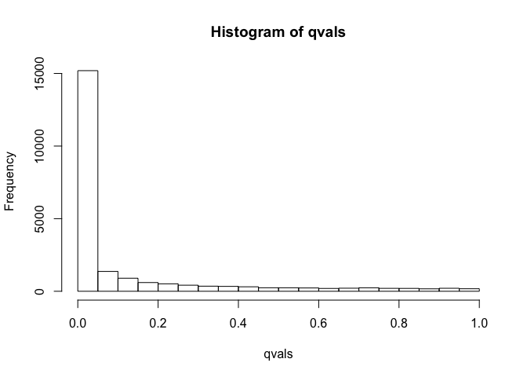

```r
pvals <- f.pvalue(edata, modmatFull, modmatNull)
qvals <- p.adjust(pvals, method = "BH")
hist(qvals)
```

```r
sum(qvals <= 0.05)
```

```
## [1] 15193
```

```r
sum(qvals <= 0.05)/length(qvals)
```

```
## [1] 0.6818202
```

We can adjust for the latent factors (surrogate variables) estimated by SVA by including them in our full and null design matrices and repeating the same analysis:

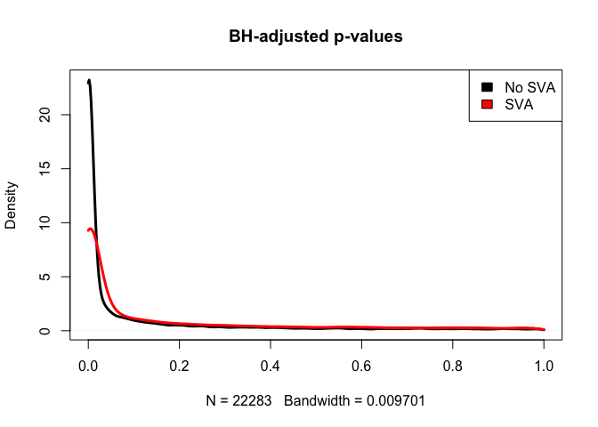

```r
modmatFullSv <- cbind(modmatFull, svobj$sv)
modmatNullSv <- cbind(modmatNull, svobj$sv)
pvalsSv <- f.pvalue(edata, modmatFullSv, modmatNullSv)
qvalsSv <- p.adjust(pvalsSv, method="BH")
plot(density(qvals, from = 0, to = 1), lwd = 3, main = "BH-adjusted p-values")
lines(density(qvalsSv, from = 0, to = 1), lwd = 3, col = "red")
legend("topright", legend = c("No SVA", "SVA"), fill = c("black", "red"))
```

```r
sum(qvalsSv <= 0.05)
```

```
## [1] 12726
```

```r
sum(qvalsSv <= 0.05)/length(qvalsSv)
```

```
## [1] 0.571108
```

## 5.2 Running limma

Because we are in a situation where we are conducting thousands of tests of differential expression, it is reasonable to use **limma**. Remember that with the design matrix that we set up earlier, the regression coefficients are interpreted as differences in expression of normal and cancer states relative to biopsy (biopsy is the reference state). Instead, let’s estimate **contrasts** of these coefficients to get all of the pairwise comparisons. Contrast 1 (C1) compares cancer samples to biopsied samples (cancer - biopsy). Contrast 2 (C2) compares normal samples to cancer samples (normal - cancer). Contrast 3 (C3) compares normal versus biopsied samples (normal - biopsy)

```r
library(limma)
# Fit linear models to get standard coefficients
fit <- lmFit(edata, modmatFullSv)
# Define contrasts
contrast.matrix <- cbind("C1" = c(0,1,0,rep(0,svobj$n.sv)),
    "C2" = c(0,-1,1,rep(0,svobj$n.sv)),
    "C3" = c(0,0,1,rep(0,svobj$n.sv)))
# Estimate contrasts
fitContrasts <- contrasts.fit(fit, contrast.matrix)
# Get moderated F-statistics
eb <- eBayes(fitContrasts)
toptab <- topTable(eb, adjust = "BH", number = Inf)
head(toptab)
```

```
##                  C1        C2         C3  AveExpr        F      P.Value
## 211585_at -1.465465 0.9111758 -0.5542888 4.584243 133.5214 1.718731e-20
## 216005_at -2.575830 0.3965069 -2.1793231 4.264339 133.2013 1.805781e-20
## 211565_at -2.774910 2.0972612 -0.6776487 5.850236 125.4930 6.124013e-20
## 216877_at -1.094936 0.4502006 -0.6447359 4.413088 122.0920 1.070960e-19
## 206786_at -1.457799 0.3816179 -1.0761810 4.232628 116.2132 2.903829e-19
## 215477_at -1.238732 0.6156730 -0.6230587 4.693242 115.8729 3.080326e-19
##              adj.P.Val
## 211585_at 2.011911e-16
## 216005_at 2.011911e-16
## 211565_at 4.548712e-16
## 216877_at 5.966050e-16
## 206786_at 1.143982e-15
## 215477_at 1.143982e-15
```

```r
sum(toptab$adj.P.Val <= 0.05)
```

```
## [1] 12753
```

```r
sum(toptab$adj.P.Val <= 0.05)/nrow(toptab)
```

```
## [1] 0.5723197
```

The two methods give roughly the same number of differentially expressed genes. Let’s go a little deeper to compare the two approaches of (1) running standard linear modeling with SVA output and (2) running **limma** with SVA output. Remember that although this dataset provides information about the batches in which the arrays were processed, SVA doesn’t use this information. We can use the provided batch information to perform a “gold standard” analysis. Use standard linear models but adjust for batch:

```r
modmatFullBatch <- model.matrix(~as.factor(cancer) + as.factor(batch), data = pheno)
modmatNullBatch <- model.matrix(~as.factor(batch), data = pheno)
pvalsBatch <- f.pvalue(edata, modmatFullBatch, modmatNullBatch)
qvalsBatch <- p.adjust(pvalsBatch, method = "BH")
sum(qvalsBatch <= 0.05)
```

```
## [1] 14786
```

```r
sum(qvalsBatch <= 0.05)/length(qvalsBatch)
```

```
## [1] 0.6635552
```

We can compare the p-values from the different methods, and it seems that the p-values from both methods are roughly following the p-values from the gold standard analysis:

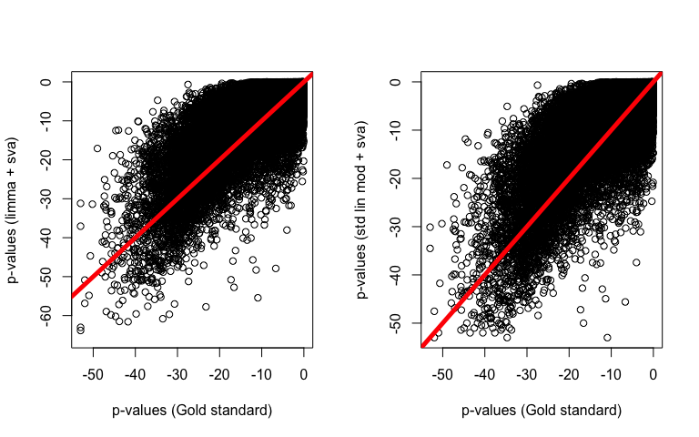

```r
par(mfrow = c(1,2))
plot(log2(pvalsBatch), log2(eb$F.p.value), xlab = "p-values (Gold standard)", ylab = "p-values (limma + sva)")
abline(a = 0, b = 1, lwd = 5, col = "red")
plot(log2(pvalsBatch), log2(pvalsSv), xlab = "p-values (Gold standard)", ylab = "p-values (std lin mod + sva)")
abline(a = 0, b = 1, lwd = 5, col = "red")
```

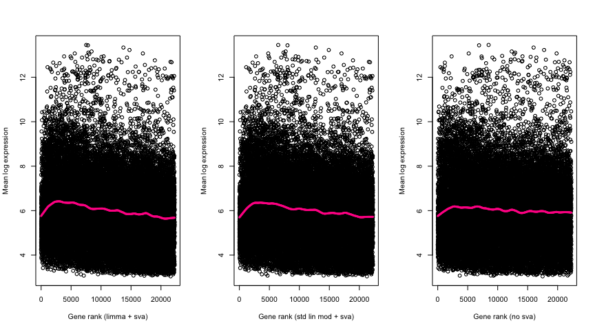

```r
par(mfrow = c(1,3))
plot(rank(eb$F.p.value), rowMeans(edata), xlab = "Gene rank (limma + sva)", ylab = "Mean log expression")
lines(lowess(rank(eb$F.p.value), rowMeans(edata), f = 0.1), lwd = 3, col = "deeppink")
plot(rank(pvalsSv), rowMeans(edata), xlab = "Gene rank (std lin mod + sva)", ylab = "Mean log expression")
lines(lowess(rank(pvalsSv), rowMeans(edata), f = 0.1), lwd = 3, col = "deeppink")
plot(rank(pvals), rowMeans(edata), xlab = "Gene rank (no sva)", ylab = "Mean log expression")
lines(lowess(rank(pvals), rowMeans(edata), f = 0.1), lwd = 3, col = "deeppink")
```

```r
library(matrixStats)
```

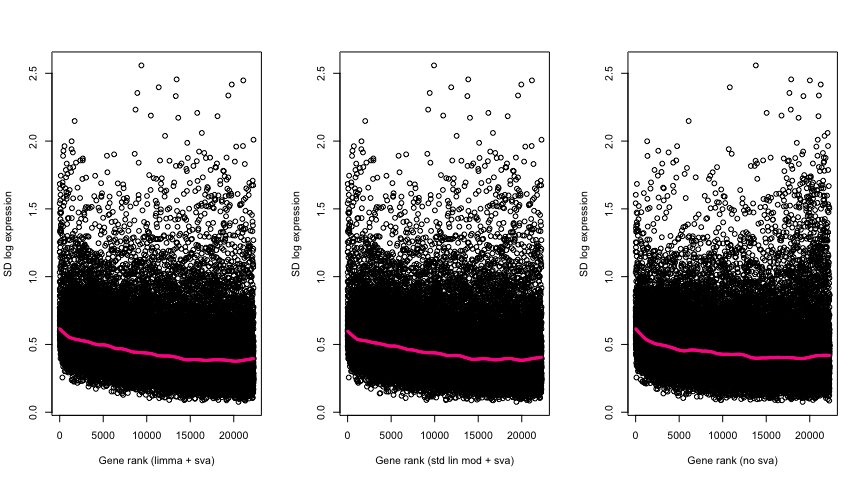

```r
par(mfrow = c(1,3))
plot(rank(eb$F.p.value), rowSds(edata), xlab = "Gene rank (limma + sva)", ylab = "SD log expression")
lines(lowess(rank(eb$F.p.value), rowSds(edata), f = 0.1), lwd = 3, col = "deeppink")
plot(rank(pvalsSv), rowSds(edata), xlab = "Gene rank (std lin mod + sva)", ylab = "SD log expression")
lines(lowess(rank(pvalsSv), rowSds(edata), f = 0.1), lwd = 3, col = "deeppink")
plot(rank(pvals), rowSds(edata), xlab = "Gene rank (no sva)", ylab = "SD log expression")
lines(lowess(rank(pvals), rowSds(edata), f = 0.1), lwd = 3, col = "deeppink")
```